# L2 Stock and Bond Return

FIN 3380: Introduction to Financial Data Analysis

Week 4-5

# Explore the stocks and short-term bonds’ performance over the last 50 years.

## Load Library and Set Directory

## Step 1: Import Fama-French Data from Professor Kenneth French’s Website. We retrieve Fama-French monthly data and save the text file (compressed initially in a ZIP file) as “F-F_Research_Data_Factors.txt”.

- The data starts on the fourth line.
- The data is of fixed-width.
- The first column of dates has six characters to the last character, the second column labeled “Mkt-RF” is eight characters after that, the third column “SMB” is eight characters after, the fourth column “HML” is eight characters after, and the last column “RF” is eight characters after.
- To import this fixed-width file, we use the read.fwf command with widths of 6, 8, 8, 8, and 8 characters while skipping the first four lines of the data.
- read.fwf(): Read a table of fixed width formatted data into a dataframe.

```r
setwd("C:/Users/siche/Documents/teaching/Introduction to Financial Data Analysis/L2")
ff.raw = read.fwf("F-F_Research_Data_Factors.txt",widths=c(6,8,8,8,8),skip=4)
head(ff.raw)
```

```
##       V1       V2       V3       V4       V5
## 1 192607     2.96    -2.30    -2.87     0.22
## 2 192608     2.64    -1.40     4.19     0.25
## 3 192609     0.36    -1.32     0.01     0.23
## 4 192610    -3.24     0.04     0.51     0.32
## 5 192611     2.53    -0.20    -0.35     0.31
## 6 192612     2.62    -0.04    -0.02     0.28
```

```r
tail(ff.raw)
```

```
##          V1       V2       V3       V4       V5
## 1208   2015     0.07    -4.05    -9.61     0.02
## 1209   2016    13.30     6.60    22.89     0.20
## 1210   2017    21.50    -4.77   -13.86     0.80
## 1211   2018    -6.93    -3.31    -9.40     1.81
## 1212   <NA>     <NA>     <NA>     <NA>     <NA>
## 1213 Copyri ght 2019  Kenneth  R. Fren       ch
```

## Step 2: Clean up data

- The bottom part of the file contains summary annual data, which we do not need. As such, we delete the data from Row 1117 to Row 1213.
- Note that since the data on Professor French’s website gets updated periodically, a later version of the file will likely end up with different row numbers.
- We delete the corresponding rows Rename V1 to V5 to something more meaningful.
- The variables are all factor variables and we need to convert the data to numeric variables.
- For the date variable, change the text.date to date variable

```r
ff.raw = ff.raw[-which(is.na(ff.raw$V1))[1]:-nrow(ff.raw),]
tail(ff.raw)
```

```
##          V1       V2       V3       V4       V5
## 1111 201901     8.41     3.02    -0.60     0.21
## 1112 201902     3.40     2.02    -2.84     0.18
## 1113 201903     1.10    -3.15    -4.07     0.19
## 1114 201904     3.96    -1.70     1.98     0.21
## 1115 201905    -6.94    -1.26    -2.38     0.21
## 1116 201906     6.93     0.36    -1.08     0.18
```

```r
colnames(ff.raw) = c("text.date","rmxrf","smb","hml","rf")
head(ff.raw)
```

```
##   text.date    rmxrf      smb      hml       rf
## 1    192607     2.96    -2.30    -2.87     0.22
## 2    192608     2.64    -1.40     4.19     0.25
## 3    192609     0.36    -1.32     0.01     0.23
## 4    192610    -3.24     0.04     0.51     0.32
## 5    192611     2.53    -0.20    -0.35     0.31
## 6    192612     2.62    -0.04    -0.02     0.28
```

```r
str(ff.raw)
```

```
## 'data.frame':    1116 obs. of  5 variables:
##  $ text.date: Factor w/ 1211 levels "      ","  1927",..: 95 96 97 98 99 100 101 102 103 104 ...
##  $ rmxrf    : Factor w/ 888 levels "  -10.05","  -10.10",..: 570 547 392 212 539 545 51 649 377 400 ...
##  $ smb      : Factor w/ 748 levels "  -11.00","  -11.79",..: 193 125 119 363 28 14 60 19 140 398 ...
##  $ hml      : Factor w/ 747 levels "  -10.04","  -10.66",..: 228 608 344 386 49 18 627 562 215 395 ...
##  $ rf       : Factor w/ 173 levels "   -0.01","   -0.02",..: 28 31 29 38 37 34 31 32 36 31 ...
```

```r
dt = ff.raw$text.date
head(dt)
```

```
## [1] 192607 192608 192609 192610 192611 192612
## 1211 Levels:          1927   1928   1929   1930   1931   1932 ... Copyri
```

```r
tail(dt)
```

```
## [1] 201901 201902 201903 201904 201905 201906
## 1211 Levels:          1927   1928   1929   1930   1931   1932 ... Copyri
```

```r
ff.raw = ff.raw[,c(-1)]

ff.raw = data.frame(apply(ff.raw,2,function(x) as.numeric(x)/100))

ff.raw$date = seq(as.Date("1926-07-01"),as.Date("2019-06-30"),by="months")

head(ff.raw)
```

```
##     rmxrf     smb     hml     rf       date
## 1  0.0296 -0.0230 -0.0287 0.0022 1926-07-01
## 2  0.0264 -0.0140  0.0419 0.0025 1926-08-01
## 3  0.0036 -0.0132  0.0001 0.0023 1926-09-01
## 4 -0.0324  0.0004  0.0051 0.0032 1926-10-01
## 5  0.0253 -0.0020 -0.0035 0.0031 1926-11-01
## 6  0.0262 -0.0004 -0.0002 0.0028 1926-12-01
```

```r
save(ff.raw,file='ff.raw.RData')

ff.raw = ff.raw[,-which(colnames(ff.raw) %in% c("smb","hml"))]
head(ff.raw)
```

```
##     rmxrf     rf       date
## 1  0.0296 0.0022 1926-07-01
## 2  0.0264 0.0025 1926-08-01
## 3  0.0036 0.0023 1926-09-01
## 4 -0.0324 0.0032 1926-10-01
## 5  0.0253 0.0031 1926-11-01
## 6  0.0262 0.0028 1926-12-01
```

## Step 3: Calculate Raw Market Return

- The Fama-French data gives us the excess market return, which is the return on the market less the risk-free rate.
- Add the risk-free rate back to get the raw market return

```r
ff.raw$rm = ff.raw$rmxrf + ff.raw$rf
head(ff.raw)
```

```
##     rmxrf     rf       date      rm
## 1  0.0296 0.0022 1926-07-01  0.0318
## 2  0.0264 0.0025 1926-08-01  0.0289
## 3  0.0036 0.0023 1926-09-01  0.0059
## 4 -0.0324 0.0032 1926-10-01 -0.0292
## 5  0.0253 0.0031 1926-11-01  0.0284
## 6  0.0262 0.0028 1926-12-01  0.0290
```

## Step 4: Subset Data from December 1968 to December 2018

- Assume we have $1 invested at the end of 1968 December.
- Use base R subset function to filter data

```r
ff = subset(ff.raw,ff.raw$date>="1968-12-01" &
            ff.raw$date<"2019-01-01")

head(ff)
```

```
##       rmxrf     rf       date      rm
## 510 -0.0394 0.0043 1968-12-01 -0.0351
## 511 -0.0125 0.0053 1969-01-01 -0.0072
## 512 -0.0584 0.0046 1969-02-01 -0.0538
## 513  0.0264 0.0046 1969-03-01  0.0310
## 514  0.0146 0.0053 1969-04-01  0.0199
## 515 -0.0010 0.0048 1969-05-01  0.0038
```

```r
ff$gross.rm = 1 + ff$rm
ff$gross.rf = 1 + ff$rf

ff$gross.rf[1]=1
ff$gross.rm[1]=1

head(ff)
```

```
##       rmxrf     rf       date      rm gross.rm gross.rf
## 510 -0.0394 0.0043 1968-12-01 -0.0351   1.0000   1.0000
## 511 -0.0125 0.0053 1969-01-01 -0.0072   0.9928   1.0053
## 512 -0.0584 0.0046 1969-02-01 -0.0538   0.9462   1.0046
## 513  0.0264 0.0046 1969-03-01  0.0310   1.0310   1.0046
## 514  0.0146 0.0053 1969-04-01  0.0199   1.0199   1.0053
## 515 -0.0010 0.0048 1969-05-01  0.0038   1.0038   1.0048
```

## Step 5: Calculate Cumulative Returns for the Market and Risk-free Rate

```r
ff$cumret.rm = cumprod(ff$gross.rm)
ff$cumret.rf = cumprod(ff$gross.rf)

save(ff,file='ff.RData')
```

## Step 6: Plot the cumulative returns

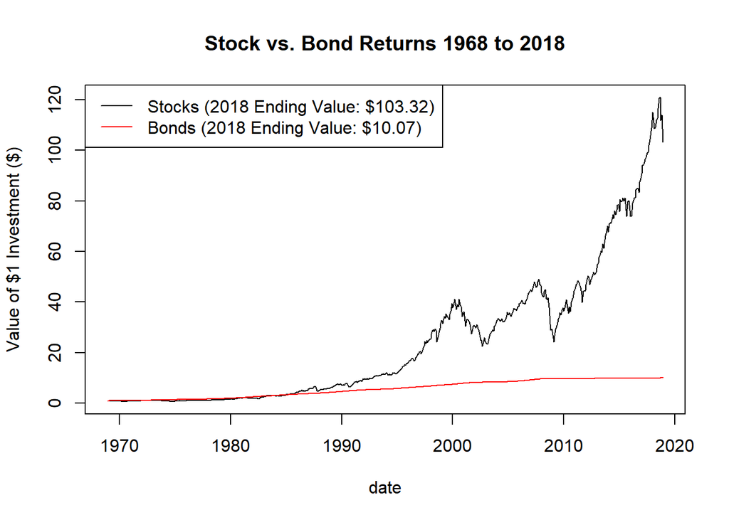

```r
yrange = range(ff$cumret.rm,ff$cumret.rf)
plot(ff$cumret.rm~as.Date(ff$date),type='l',
     ylab='Value of $1 Investment ($)',xlab='date',
     main='Stock vs. Bond Returns 1968 to 2018')
lines(ff$cumret.rf~as.Date(ff$date),col='red')
legend("topleft",
       c(paste0("Stocks (2018 Ending Value: $", round(ff$cumret.rm[nrow(ff)],2),")"),
         paste0("Bonds (2018 Ending Value: $",
round(ff$cumret.rf[nrow(ff)],2),")")),
       lty=c(1,1),
       col=c("black","red"))
```

## Step 7: Plot Stock and Bond Returns as demonstration of their volatilities

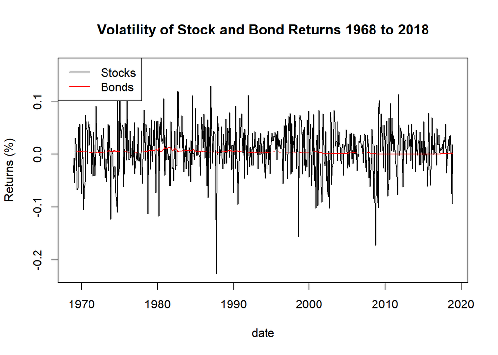

```r
yrange = range(ff$rm,ff$rf)
plot(ff$rm~as.Date(ff$date),type='l',
     ylab='Returns (%)',xlab='date',
     main='Volatility of Stock and Bond Returns 1968 to 2018')
lines(ff$rf~as.Date(ff$date),col='red')
legend("topleft",
       c("Stocks",
         "Bonds"),
       lty=c(1,1),
       col=c("black","red"))
```

# Asset Allocation

## Step 1: Load the 10 year bond and equity return data

```r
load("C:/Users/siche/Documents/teaching/Introduction to Financial Data Analysis/L2/eq.bond.RData")
head(eq.bond)
```

```
##         date      sp500    bond10y          rf
## 1 1962-03-31 -0.0054600  0.0127560 0.001666667
## 2 1962-04-30 -0.0608186  0.0018875 0.001666667
## 3 1962-05-31 -0.0843448 -0.0010309 0.001666667
## 4 1962-06-30 -0.0781284 -0.0041314 0.001666667
## 5 1962-07-31  0.0662528 -0.0001259 0.001666667
## 6 1962-08-31  0.0161290  0.0079269 0.001666667
```

## Step 2: Calculate the bond and equity’s std, return, cov, corr

```r
ret.eq = mean(eq.bond$sp500)*12
ret.eq
```

```
## [1] 0.06651942
```

```r
ret.bond = mean(eq.bond$bond10y)*12
ret.bond
```

```
## [1] 0.03064203
```

```r
sd.eq = sd(eq.bond$sp500)*sqrt(12)
sd.eq
```

```
## [1] 0.1510999
```

```r
sd.bond = sd(eq.bond$bond10y)*sqrt(12)
sd.bond
```

```
## [1] 0.0771966
```

```r
corr.eq.bond = cor(eq.bond$sp500,eq.bond$bond10y)
corr.eq.bond
```

```
## [1] 0.1670368
```

```r
cov.eq.bond = cov(eq.bond$sp500,eq.bond$bond10y)*12
cov.eq.bond
```

```
## [1] 0.001948384
```

## Step 3: Investment opportunity set: Efficient frontier

- Create a dataframe with weights of equity, weights of bond

```r
ef = data.frame(wgt.eq=seq(0,1,0.1),
                wgt.bond=seq(1,0,-0.1))
head(ef)
```

```
##   wgt.eq wgt.bond
## 1    0.0      1.0
## 2    0.1      0.9
## 3    0.2      0.8
## 4    0.3      0.7
## 5    0.4      0.6
## 6    0.5      0.5
```

- Given the standard deviation of equity, bond and their correlation, calculate the portfolio std and ret for each weight.

```r
ef = ef %>% mutate(sd.port=sqrt(wgt.eq^2*sd.eq^2 + wgt.bond^2*sd.bond^2 + 2*wgt.eq*wgt.bond*cov.eq.bond),
                   ret.port=wgt.eq*ret.eq+wgt.bond*ret.bond)
ef
```

```
##    wgt.eq wgt.bond    sd.port   ret.port
## 1     0.0      1.0 0.07719660 0.03064203
## 2     0.1      0.9 0.07352596 0.03422977
## 3     0.2      0.8 0.07314842 0.03781751
## 4     0.3      0.7 0.07611302 0.04140525
## 5     0.4      0.6 0.08205831 0.04499299
## 6     0.5      0.5 0.09039809 0.04858073
## 7     0.6      0.4 0.10053824 0.05216846
## 8     0.7      0.3 0.11199078 0.05575620
## 9     0.8      0.2 0.12439376 0.05934394
## 10    0.9      0.1 0.13749019 0.06293168
## 11    1.0      0.0 0.15109988 0.06651942
```

## Step 4: Visualize portfolio return for each weight, standard deviation for each weight and efficient frontier(the relationship between portfolio return and std)

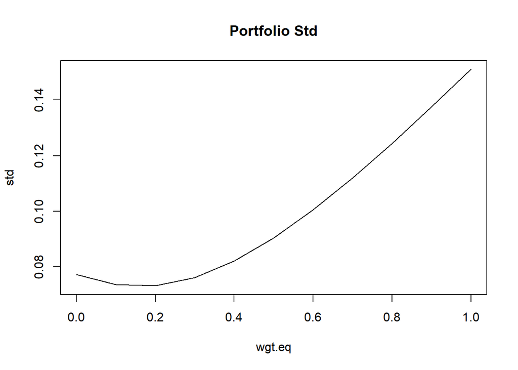

```r
plot(ef$sd.port~ef$wgt.eq,type='l',main='Portfolio Std',xlab='wgt.eq',ylab='std')
```

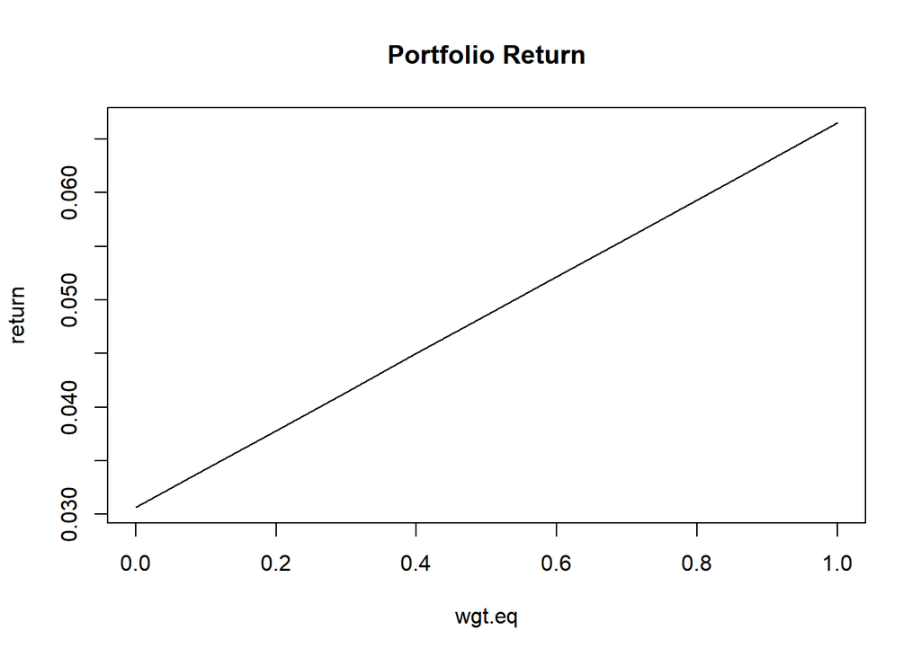

```r
plot(ef$ret.port~ef$wgt.eq,type='l',main='Portfolio Return',xlab='wgt.eq',ylab='return')
```

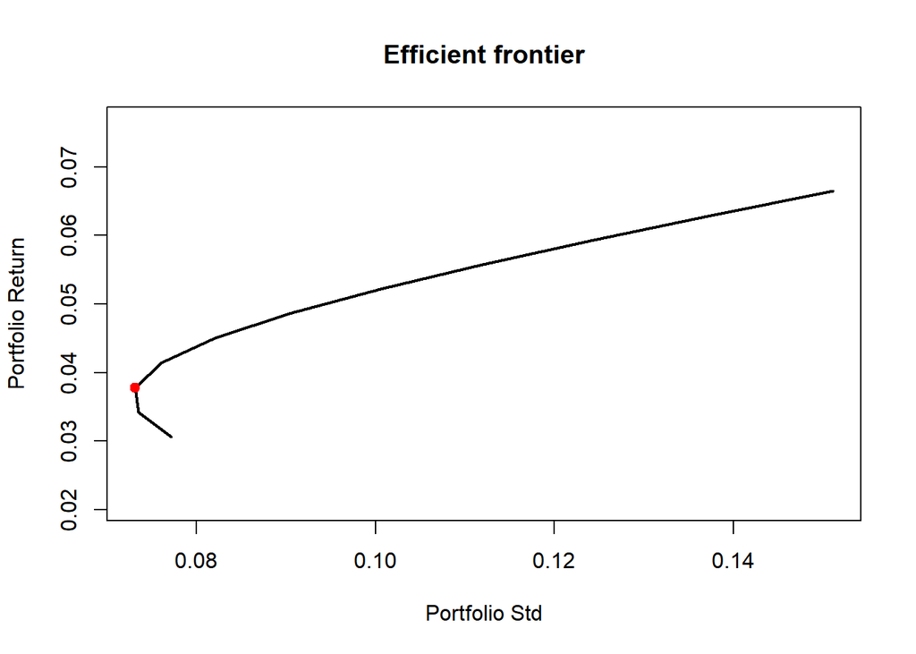

```r
plot(ef$ret.port~ef$sd.port,type='l',
     lwd=2,
     main='Efficient frontier',
     xlab='Portfolio Std',
     ylab='Portfolio Return',
     ylim=c(min(ef$ret.port)-0.01,max(ef$ret.port)+0.01))
gmv=ef[which(ef$sd.port==min(ef$sd.port)),c("sd.port","ret.port")]
points(gmv,pch=19,col='red')
```

## Step 5: Complete Portfolio: Capital Allocation Line (CAL)

```r
risky = ef[3,c("ret.port","sd.port")]
rf = data.frame(ret.rf=mean(eq.bond$rf)*12,sd.rf=0)
```

- Calculate the corresponding return and std of the portfolio with the risk-free asset
  - The weights of the risk-free asset ranges from -100% to 100%

```r
cal = data.frame(wgt.riskfree = seq(-1,1,0.1))
head(cal)
```

```
##   wgt.riskfree
## 1         -1.0
## 2         -0.9
## 3         -0.8
## 4         -0.7
## 5         -0.6
## 6         -0.5
```

```r
cal = cal %>% mutate(wgt.risky = 1-wgt.riskfree,
                     ret.rf=rf$ret.rf,
                     ret.risky=risky$ret.port,
                     sd.risky=risky$sd.port)
cal = cal %>%
  mutate(ret.cal = wgt.riskfree*ret.rf + wgt.risky*ret.risky,
         sd.cal = wgt.risky*sd.risky)
head(cal)
```

```
##   wgt.riskfree wgt.risky ret.rf  ret.risky   sd.risky    ret.cal    sd.cal
## 1         -1.0       2.0   0.02 0.03781751 0.07314842 0.05563502 0.1462968
## 2         -0.9       1.9   0.02 0.03781751 0.07314842 0.05385327 0.1389820
## 3         -0.8       1.8   0.02 0.03781751 0.07314842 0.05207152 0.1316672
## 4         -0.7       1.7   0.02 0.03781751 0.07314842 0.05028977 0.1243523
## 5         -0.6       1.6   0.02 0.03781751 0.07314842 0.04850802 0.1170375
## 6         -0.5       1.5   0.02 0.03781751 0.07314842 0.04672627 0.1097226
```

## Step 6: Visualize and calculate the Sharpe ratio

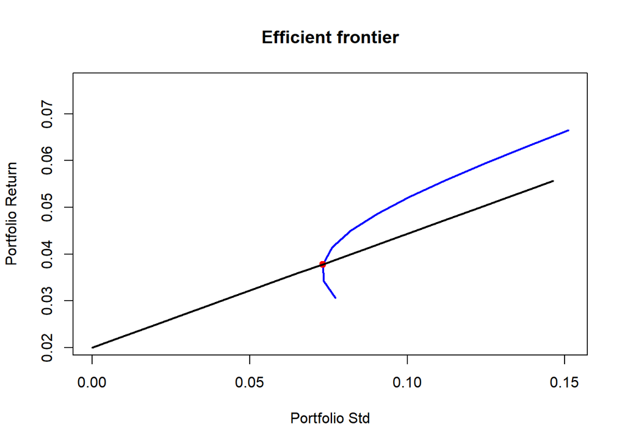

```r
plot(ef$ret.port~ef$sd.port,type='l',
     lwd=2,xlim=c(0,max(ef$sd.port)),
     main='Efficient frontier',
     xlab='Portfolio Std',
     ylab='Portfolio Return',
     ylim=c(min(ef$ret.port)-0.01,max(ef$ret.port)+0.01),
     col='blue')
gmv=ef[which(ef$sd.port==min(ef$sd.port)),c("sd.port","ret.port")]
points(gmv,pch=19,col='red')

lines(cal$ret.cal~cal$sd.cal,
     type='l',
     xlab='std',
     ylab='return',
     main='CAL',
     lwd=2)
```

```r
sharpe=(risky$ret.port-rf$ret.rf)/risky$sd.port
sharpe
```

```
## [1] 0.2435802
```

## Step 6: Find the optimal allocation with a risk-free asset: CML

- Calculate the sharpe ratio for different combinations of equity and bond allocation

```r
ef = ef %>% mutate(rf = rf$ret.rf,
                   sr = (ret.port-rf)/sd.port)
head(ef)
```

```
##   wgt.eq wgt.bond    sd.port   ret.port   rf        sr
## 1    0.0      1.0 0.07719660 0.03064203 0.02 0.1378563
## 2    0.1      0.9 0.07352596 0.03422977 0.02 0.1935340
## 3    0.2      0.8 0.07314842 0.03781751 0.02 0.2435802
## 4    0.3      0.7 0.07611302 0.04140525 0.02 0.2812298
## 5    0.4      0.6 0.08205831 0.04499299 0.02 0.3045760
## 6    0.5      0.5 0.09039809 0.04858073 0.02 0.3161652
```

- Find the allocation with the highest sharpe ratio

```r
cml = ef[which(ef$sr==max(ef$sr)),]
print(cml)
```

```
##   wgt.eq wgt.bond   sd.port   ret.port   rf        sr
## 7    0.6      0.4 0.1005382 0.05216846 0.02 0.3199625
```